# XAI_hw3

We'll use the "MagicTelescope" dataset. The data is generated to simulate registration of high energy gamma particles. The TARGET column has values either:

- `g` - gamma (signal) - we'll denote by 0,
- `h` - hadron (background) - we'll denote by 1.

We'll also shuffle the data, just in case, to remove any potential bias encoded in the data order.

|  | fLength: | fWidth: | fSize: | fConc: | fConc1: | fAsym: | fM3Long: | fM3Trans: | fAlpha: | fDist: |
| --- | --- | --- | --- | --- | --- | --- | --- | --- | --- | --- |
| count | 19020.000000 | 19020.000000 | 19020.000000 | 19020.000000 | 19020.000000 | 19020.000000 | 19020.000000 | 19020.000000 | 19020.000000 | 19020.000000 |
| mean | 53.250154 | 22.180966 | 2.825017 | 0.380327 | 0.214657 | -4.331745 | 10.545545 | 0.249726 | 27.645707 | 193.818026 |
| std | 42.364855 | 18.346056 | 0.472599 | 0.182813 | 0.110511 | 59.206062 | 51.000118 | 20.827439 | 26.103621 | 74.731787 |
| min | 4.283500 | 0.000000 | 1.941300 | 0.013100 | 0.000300 | -457.916100 | -331.780000 | -205.894700 | 0.000000 | 1.282600 |
| 25% | 24.336000 | 11.863800 | 2.477100 | 0.235800 | 0.128475 | -20.586550 | -12.842775 | -10.849375 | 5.547925 | 142.492250 |
| 50% | 37.147700 | 17.139900 | 2.739600 | 0.354150 | 0.196500 | 4.013050 | 15.314100 | 0.666200 | 17.679500 | 191.851450 |
| 75% | 70.122175 | 24.739475 | 3.101600 | 0.503700 | 0.285225 | 24.063700 | 35.837800 | 10.946425 | 45.883550 | 240.563825 |
| max | 334.177000 | 256.382000 | 5.323300 | 0.893000 | 0.675200 | 575.240700 | 238.321000 | 179.851000 | 90.000000 | 495.561000 |

Let's create an xgboost classifier and a corresponding `dalex` explainer.

```
Preparation of a new explainer is initiated

  -> data              : 19020 rows 10 cols
  -> target variable   : Parameter 'y' was a pandas.Series. Converted to a numpy.ndarray.
  -> target variable   : 19020 values
  -> model_class       : xgboost.sklearn.XGBClassifier (default)
  -> label             : Not specified, model's class short name will be used. (default)
  -> predict function  : <function yhat_proba_default at 0x7e3b47873130> will be used (default)
  -> predict function  : Accepts pandas.DataFrame and numpy.ndarray.
  -> predicted values  : min = 0.000114, mean = 0.352, max = 1.0
  -> model type        : classification will be used (default)
  -> residual function : difference between y and yhat (default)
  -> residuals         : min = -0.936, mean = 4.48e-05, max = 0.981
  -> model_info        : package xgboost

A new explainer has been created!
```

The performance of the model:

|  | recall | precision | f1 | accuracy | auc |
| --- | --- | --- | --- | --- | --- |
| XGBClassifier | 0.863487 | 0.955335 | 0.907092 | 0.937802 | 0.98288 |

Let's focus on, for example, the first observation from the shuffled dataset.

```
Prediction for observation 0: 0.9970188140869141
```

Let's see if these observations are stable. To achieve that, we'll re-run the explainer on the same sample a 100 times (with different seeds). The result, in a box-scatter plot format are as follows:

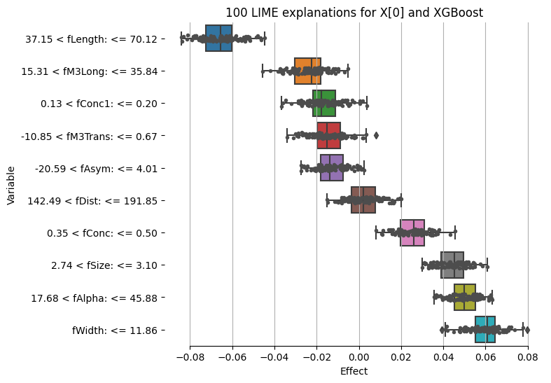

As we can see, the results are quite stable. We can also confirm it by calculating the standard deviation for each variable, which in all cases is below `0.01`.

| variable | mean | std |
| --- | --- | --- |
| -10.85 < fM3Trans: <= 0.67 | -0.014825 | 0.008363 |
| -20.59 < fAsym: <= 4.01 | -0.012887 | 0.007238 |
| 0.13 < fConc1: <= 0.20 | -0.016643 | 0.008335 |
| 0.35 < fConc: <= 0.50 | 0.025722 | 0.007231 |
| 142.49 < fDist: <= 191.85 | 0.002083 | 0.007779 |
| 15.31 < fM3Long: <= 35.84 | -0.023836 | 0.008352 |
| 17.68 < fAlpha: <= 45.88 | 0.050053 | 0.006799 |
| 2.74 < fSize: <= 3.10 | 0.044312 | 0.006997 |
| 37.15 < fLength: <= 70.12 | -0.065767 | 0.009109 |
| fWidth: <= 11.86 | 0.059718 | 0.007858 |

Let's now see, how does each of the features influence the result on a sample of a 100 observations. We'll also visualize it using the box-scatter plot format.

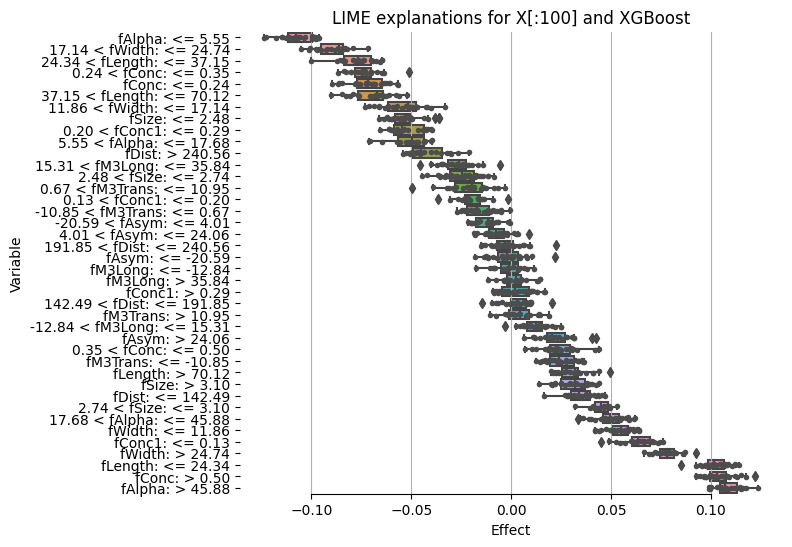

Now we'll do the same for a k-NN classifier with $k=5$.

```
KNeighborsClassifier()
```

```
Preparation of a new explainer is initiated

  -> data              : 19020 rows 10 cols
  -> target variable   : Parameter 'y' was a pandas.Series. Converted to a numpy.ndarray.
  -> target variable   : 19020 values
  -> model_class       : sklearn.neighbors._classification.KNeighborsClassifier (default)
  -> label             : Not specified, model's class short name will be used. (default)
  -> predict function  : <function yhat_proba_default at 0x7e3b47873130> will be used (default)
  -> predict function  : Accepts pandas.DataFrame and numpy.ndarray.
```

```
X does not have valid feature names, but KNeighborsClassifier was fitted with feature names
```

```
  -> predicted values  : min = 0.0, mean = 0.319, max = 1.0
  -> model type        : classification will be used (default)
  -> residual function : difference between y and yhat (default)
  -> residuals         : min = -0.8, mean = 0.0326, max = 0.8
  -> model_info        : package sklearn

A new explainer has been created!
```

Model performance:

|  | recall | precision | f1 | accuracy | auc |
| --- | --- | --- | --- | --- | --- |
| KNeighborsClassifier | 0.69064 | 0.885375 | 0.775976 | 0.859779 | 0.940409 |

Stability of prediction for $X[0]$.

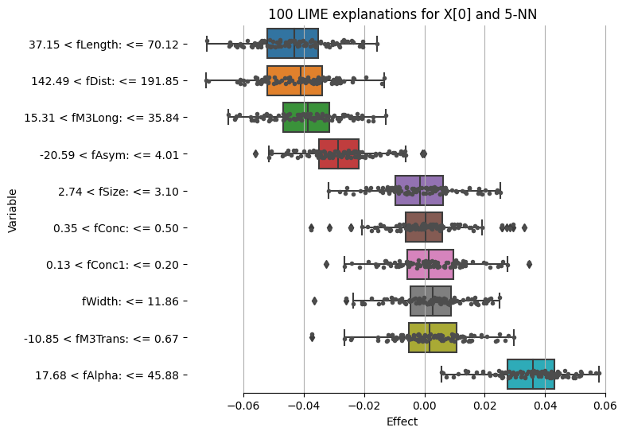

Variable influence on a 100 samples:

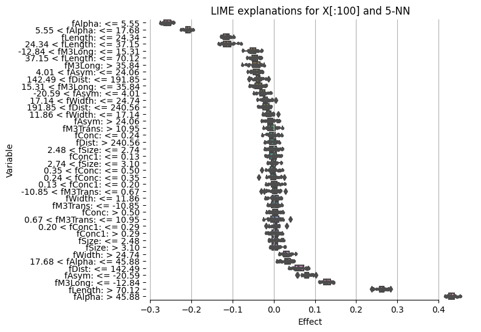

As we can see from the plots, both models consider, among others, `fLength`, `fAlpha` parameters important. Let's project $X$ onto those axes, and see visually how do they influence the result when combined.

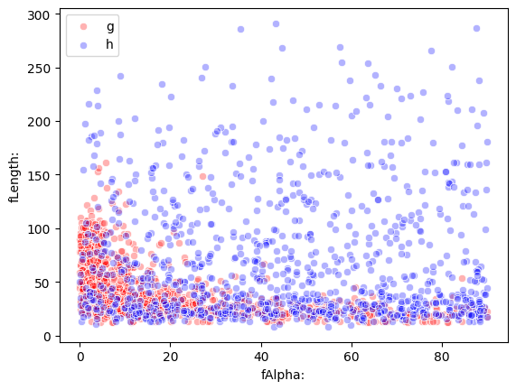

Let's now compare the results for the XGBoost model between LIME and SHAP.

SHAP explanation for $X[0]$:

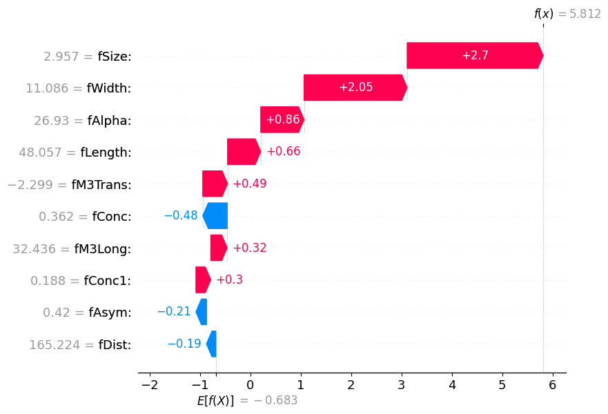

LIME explanation for $X[0]$:

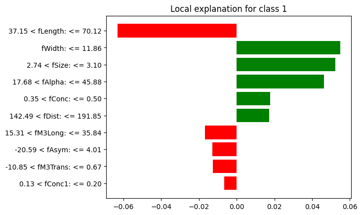